# Steam_Table_Rmd

Doku Prince

2024-10-20

# CASE STUDY (PROJECT)

This Project is about analyzing steam table values for saturated water for various temperature and pressure. Visualizations were later generated after the analysis. This case study is undertaken to avoid the idea of interpolation when reading and analyzing data from steam table. The visualization helps to solve this problem by just reading the values needed directly from the plots or graphs obtained.

## The Visualizations generated include

- Scatter Plots
- Line Plots

# MARKDOWN DOCUMENT ABOUT STEAM TABLE ANALYSIS

This document entails the downloading of steam table data set, cleaning of the data set using Microsoft excel, installing of package, loading of the package, importing and reading of data set, viewing data set and it’s summary, generation of scatter plots and line plots and documentation of the whole process.

## Downloading of dataset

The data set for this case study is obtained from the learn chemE page online [steam table values](https://learncheme.com/student-resources/steam-tables/)

## Data Cleaning Process involves:

- Importing data set into Microsoft Excel
- Removal of duplicates in data set
- Change data set into same datatype i.e(numeric)
- Use of conditional formatting to enable cleaning
- Handle missing values
- Save workbook after cleaning

## Installing and loading of tidyverse package

```r
install.packages("tidyverse")
library(tidyverse)
```

## Importing and loading of xlsx Package

```r
install.packages("xlsx")
library(xlsx)
```

## Importing and Reading of dataset

The dataset is imported, read and assigned to data_1 for easy reference

```r
library(readxl)
data_1 <- read_excel(" Clean Data L (2).xlsx",                                 col_types = c("numeric", "numeric"))
```

## Viewing dataset and it’s summary

```r
print(data_1)
```

```
## # A tibble: 272 × 2
##    `Pressure (MPa)` `Temperature (°C)`
##               <dbl>              <dbl>
##  1         0.000612               0.01
##  2         0.0007                 1.88
##  3         0.0008                 3.76
##  4         0.0009                 5.44
##  5         0.001                  6.97
##  6         0.0012                 9.65
##  7         0.0014                12.0
##  8         0.0016                14.0
##  9         0.0018                15.8
## 10         0.002                 17.5
## # ℹ 262 more rows
```

```r
str(data_1)
```

```
## tibble [272 × 2] (S3: tbl_df/tbl/data.frame)
##  $ Pressure (MPa)  : num [1:272] 0.000612 0.0007 0.0008 0.0009 0.001 ...
##  $ Temperature (°C): num [1:272] 0.01 1.88 3.76 5.44 6.97 ...
```

```r
summary(data_1)
```

```
##  Pressure (MPa)      Temperature (°C)
##  Min.   : 0.000612   Min.   :  0.01
##  1st Qu.: 0.277500   1st Qu.:130.90
##  Median : 2.550000   Median :225.00
##  Mean   : 5.635143   Mean   :213.58
##  3rd Qu.: 9.325000   3rd Qu.:305.90
##  Max.   :22.060000   Max.   :373.90
```

## Generation of Scatter Plots

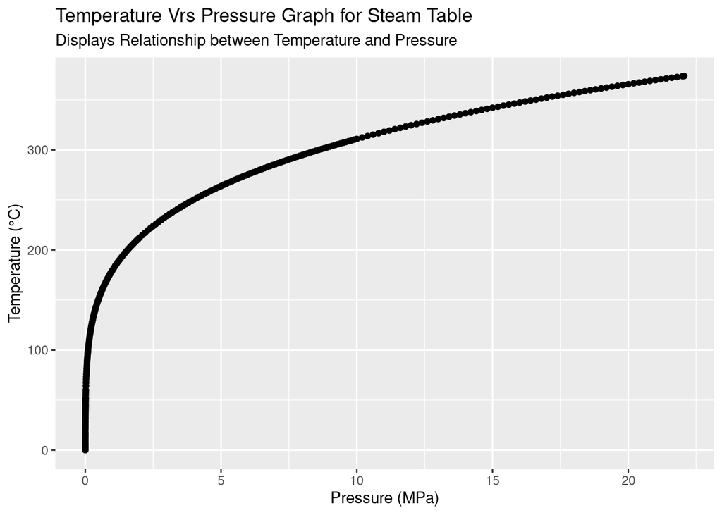

```r
library(ggplot2)
ggplot(data=data_1) +geom_point(mapping =aes(x=`Pressure (MPa)`, y = `Temperature (°C)`))+
  labs(title="Temperature Vrs Pressure Graph for Steam Table", subtitle = "Displays Relationship between Temperature and Pressure")
```

## Generation of Line Plots

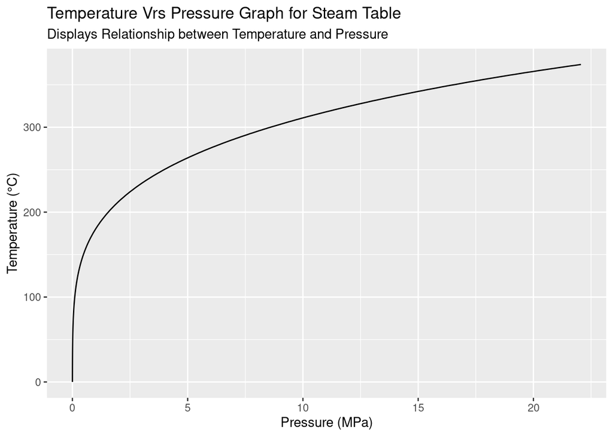

```r
ggplot(data=data_1) +geom_line(mapping =aes(x=`Pressure (MPa)`, y = `Temperature (°C)`))+
  labs(title="Temperature Vrs Pressure Graph for Steam Table", subtitle = "Displays Relationship between Temperature and Pressure")+
  xlim(0.0006117,22.06)+
  ylim(0.010,373.9)
```